# BST 260 - Homework 0

Author

Alena Figueroa

## Exercises

1. Define variables $a$, $b$, and $c$ and print the real-valued solutions to $f(x) = ax^2 + bx + c = 0$.

```
[1] There are two real solutions to f(x) = ax² + bx + c when a = 1, b = 3,
[2] and c = 2. The solutions are x = -2 and x = -1.
```

2. Plot $f(x)$ versus $x$ for $x \in (-5,5)$ to confirm the solutions found in (1).

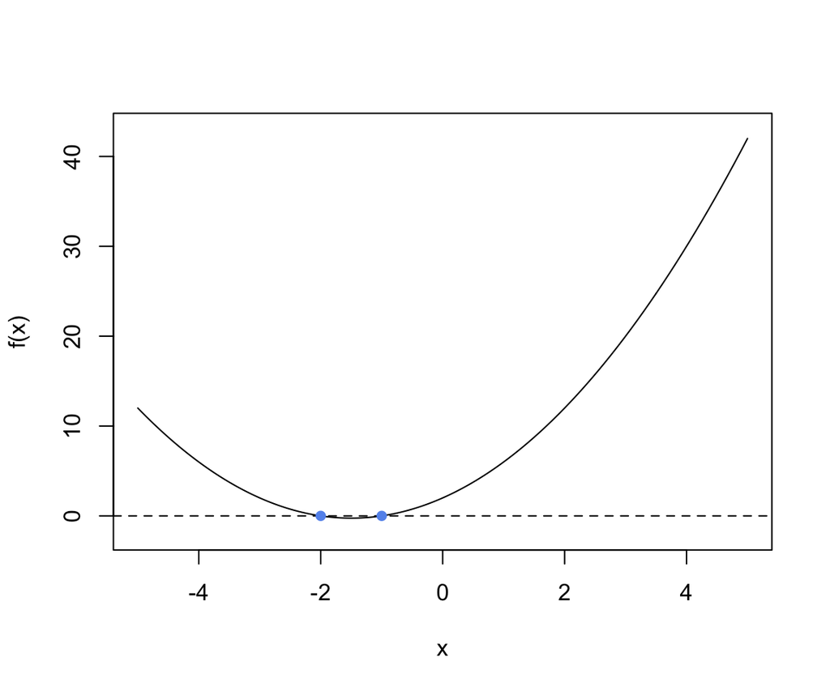

The solid black curve (i.e., the parabola) in the plot above shows the graph of the quadratic function $f(x) = ax^2 + bx + c$ for $x \in (-5,5)$ for a given $a$, $b$, and $c$ (defined above). The points where the curve and horizontal line at $f(x) = 0$ intersect are the real-valued solutions to $f(x) = ax^2 + bx + c = 0$. That is, the points of intersection provide the real-values of $x$ for which the function $f(x) = ax^2 + bx + c = 0$. If the curve and horizontal line do not intersect, there are no real-values of $x$ for which the function $f(x) = ax^2 + bx + c = 0$. If the curve and horizontal line intersect at one point or two points, then there are either one or two real-valued solutions, respectively. In the case where $a = 1$, $b = 3$, and $c = 2$, there are two real solutions at $x = -2$ and $x = -1$, which is confirmed in the plot since there are two points of intersection that correspond to these values of $x$.